# Solutions to Ch3: Data Preparation

MATH 456 - Spring 2016

Right click the link and choose “save link as” to download the [RMD] file that created these solutions.

# Intial setup

It is good practice (and good coding form) to load all libraries and read in all data sets used in the document in the first code chunk. This is also where you would want to set any global options.

```r
# Libraries
library(knitr); library(rmarkdown)
library(ggplot2);library(gridExtra)
library(car); library(readxl)
library(dplyr)

# Global options: don't show warnings or messages generated by code chunks
opts_chunk$set(warning=FALSE, message=FALSE)

# Read in all data
depress <- read.table("C:/GitHub/MATH456/data/Depress.txt", sep="\t", header=TRUE)
hiv     <- read_excel("C:/GitHub/MATH456/data/Parhiv.xlsx")
```

#### On Your Own: Data Wrangling

1. **Using the depression data set, create a new variable that collapses the first three education levels.**

```r
depress$EDUCAT <- factor(depress$EDUCAT,
                          labels = c("<HS", "Some HS", "HS Grad", "Some college", "BS", "MS", "PhD"))
depress$EDUCAT2 <- recode(depress$EDUCAT, "'<HS' = 'Up to HS grad';
                                           'Some HS' = 'Up to HS grad';
                                           'HS Grad' = 'Up to HS grad'")
```

Confirm your recode by displaying a contingency table of the old variable `EDUCAT` against your new variable. Be sure to use the `useNA="always"` argument in the `table()` statement.

```r
table(depress$EDUCAT, depress$EDUCAT2, useNA="always")
```

```
##
##                 BS  MS PhD Some college Up to HS grad <NA>
##   <HS            0   0   0            0             5    0
##   Some HS        0   0   0            0            61    0
##   HS Grad        0   0   0            0           114    0
##   Some college   0   0   0           48             0    0
##   BS            43   0   0            0             0    0
##   MS             0  14   0            0             0    0
##   PhD            0   0   9            0             0    0
##   <NA>           0   0   0            0             0    0
```

Recode confirmed. The 5 people with less than HS, 61 with some HS, and the 114 HS grads are now labeled *Up to HS grad* using the variable `EDUCAT2`.

2. **What can you say about the relationship between Income and Educational level?**  
   One common way to examine the distribution of a continuous variable `Income` across levels of a categorical variable `Education` is to create side by side boxplots. Using the code from the lecture notes that creates this plot across marital status, and updating the x variable from `MARITAL` to `EDUCAT2` we get the following plot.

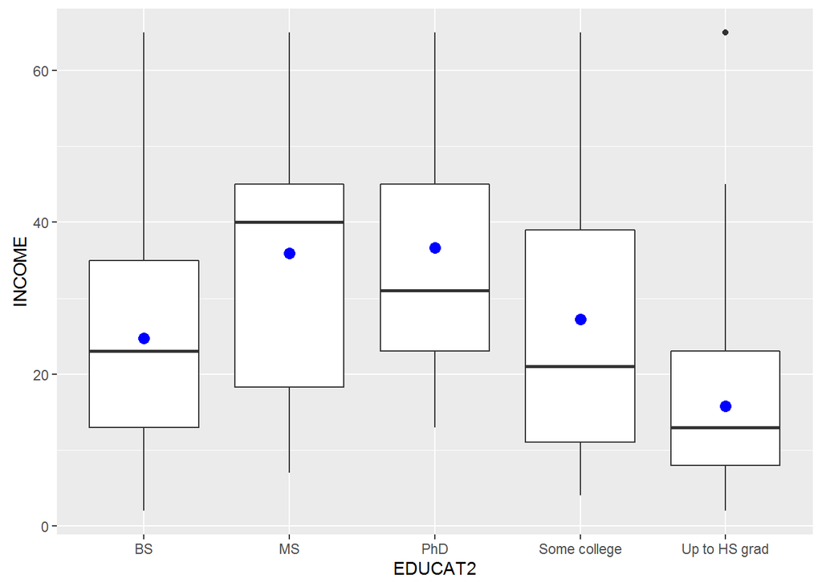

```r
qplot(y=INCOME, x=EDUCAT2, data=depress, geom="boxplot") +
   stat_summary(fun.y=mean, colour="blue", size=3, geom="point")
```

Notice carefully now that if you read left to right, education level does not strictly increase. Specifically notice that the categories are displayed in alphabetical order, not in any order that makes reasonable sense. This can be adjusted by specifying the ordering of the levels of the factor variable. The code for this solution was found on http://www.cookbook-r.com/Manipulating_data/Changing_the_order_of_levels_of_a_factor/

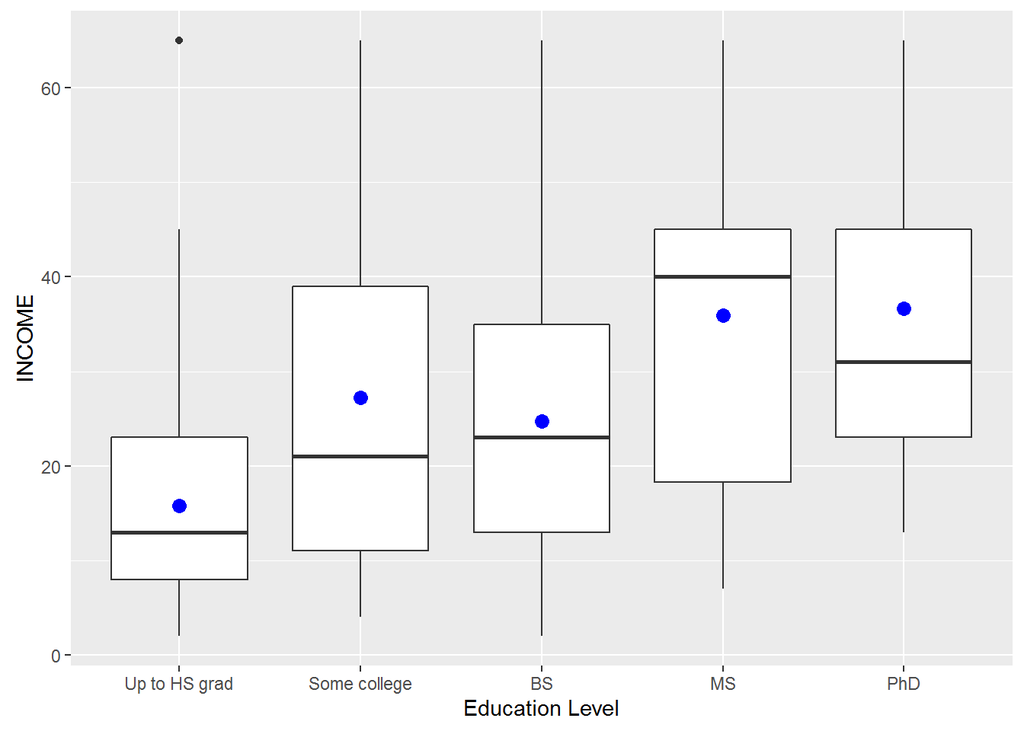

```r
depress$EDUCAT2 <- factor(depress$EDUCAT2,
                          levels=c("Up to HS grad", "Some college", "BS", "MS", "PhD"))
qplot(y=INCOME, x=EDUCAT2, data=depress, geom="boxplot", xlab="Education Level") +
   stat_summary(fun.y=mean, colour="blue", size=3, geom="point")
```

Note that this reordering could have been done in a single step when we first converted the `EDUCAT` variable to a factor variable, but not the new `EDUCAT2` variable.

```r
# Example code to create a factor variable and define the levels at the same time.
depress$EDUCAT <- factor(depress$EDUCAT,
                          labels = c("<HS", "Some HS", "HS Grad", "Some college", "BS", "MS", "PhD"),
                          levels = c("<HS", "Some HS", "HS Grad", "Some college", "BS", "MS", "PhD"))
```

3. **Determine if any variables in the depression data set have observations that do not fall within the ranges given in the codebook. If there are any, decide what to do with those values and implement your decision.** There are a lot of variables in the Depression data set, so (for me) the easiest way to visually confirm that all values are within the expected range is to do a summary of the entire data set. This produces a lot of output, but I can then go through each variable one by one, and cross-check the data against what is written in the codebook.

Notice now that `SEX` is still being treated as numeric with values 1 and 2, but `EDUCAT` now is being displayed properly as a categorical variable with our specified labels.

```r
summary(depress)
```

```
##        ID              SEX             AGE           MARITAL
##  Min.   :  1.00   Min.   :1.000   Min.   : 9.00   Min.   :1.000
##  1st Qu.: 74.25   1st Qu.:1.000   1st Qu.:28.00   1st Qu.:2.000
##  Median :147.50   Median :2.000   Median :42.50   Median :2.000
##  Mean   :147.50   Mean   :1.622   Mean   :44.38   Mean   :2.374
##  3rd Qu.:220.75   3rd Qu.:2.000   3rd Qu.:59.00   3rd Qu.:3.000
##  Max.   :294.00   Max.   :2.000   Max.   :89.00   Max.   :5.000
##
##           EDUCAT        EMPLOY          INCOME          RELIG
##  <HS         :  5   Min.   :1.000   Min.   : 2.00   Min.   :1.000
##  Some HS     : 61   1st Qu.:1.000   1st Qu.: 9.00   1st Qu.:1.000
##  HS Grad     :114   Median :1.000   Median :15.00   Median :1.000
##  Some college: 48   Mean   :2.109   Mean   :20.57   Mean   :1.983
##  BS          : 43   3rd Qu.:3.000   3rd Qu.:28.00   3rd Qu.:3.000
##  MS          : 14   Max.   :7.000   Max.   :65.00   Max.   :6.000
##  PhD         :  9
##        C1               C2              C3               C4
##  Min.   :0.0000   Min.   :0.000   Min.   :0.0000   Min.   :0.0000
##  1st Qu.:0.0000   1st Qu.:0.000   1st Qu.:0.0000   1st Qu.:0.0000
##  Median :0.0000   Median :0.000   Median :0.0000   Median :0.0000
##  Mean   :0.3639   Mean   :0.568   Mean   :0.5442   Mean   :0.1939
##  3rd Qu.:0.0000   3rd Qu.:1.000   3rd Qu.:1.0000   3rd Qu.:0.0000
##  Max.   :3.0000   Max.   :3.000   Max.   :3.0000   Max.   :3.0000
##
##        C5              C6               C7               C8
##  Min.   :0.000   Min.   :0.0000   Min.   :0.0000   Min.   :0.0000
##  1st Qu.:0.000   1st Qu.:0.0000   1st Qu.:0.0000   1st Qu.:0.0000
##  Median :0.000   Median :0.0000   Median :0.0000   Median :0.0000
##  Mean   :0.551   Mean   :0.2483   Mean   :0.2449   Mean   :0.3503
##  3rd Qu.:1.000   3rd Qu.:0.0000   3rd Qu.:0.0000   3rd Qu.:0.0000
##  Max.   :3.000   Max.   :3.0000   Max.   :3.0000   Max.   :3.0000
##
##        C9             C10              C11              C12
##  Min.   :0.000   Min.   :0.0000   Min.   :0.0000   Min.   :0.0000
##  1st Qu.:0.000   1st Qu.:0.0000   1st Qu.:0.0000   1st Qu.:0.0000
##  Median :0.000   Median :0.0000   Median :0.0000   Median :0.0000
##  Mean   :0.568   Mean   :0.4626   Mean   :0.3605   Mean   :0.5136
##  3rd Qu.:1.000   3rd Qu.:1.0000   3rd Qu.:1.0000   3rd Qu.:1.0000
##  Max.   :3.000   Max.   :3.0000   Max.   :3.0000   Max.   :3.0000
##
```

[output cut: 25 more lines]

```
##  Min.   :1.000   Min.   :1.000   Min.   :0.0000   Min.   :0.0000
##  1st Qu.:1.000   1st Qu.:1.000   1st Qu.:0.0000   1st Qu.:0.0000
##  Median :1.000   Median :1.000   Median :0.0000   Median :0.0000
##  Mean   :1.187   Mean   :1.497   Mean   :0.2143   Mean   :0.2959
##  3rd Qu.:1.000   3rd Qu.:2.000   3rd Qu.:0.0000   3rd Qu.:1.0000
##  Max.   :2.000   Max.   :2.000   Max.   :1.0000   Max.   :1.0000
##
##     CHRONILL               EDUCAT2
##  Min.   :0.0000   Up to HS grad:180
##  1st Qu.:0.0000   Some college : 48
##  Median :1.0000   BS           : 43
##  Mean   :0.5068   MS           : 14
##  3rd Qu.:1.0000   PhD          :  9
##  Max.   :1.0000
##
```

```r
table(depress$RELIG)
```

```
##
##   1   2   3   4   6
## 155  51  30  56   2
```

Without any other information to indicate what the correct response should have been, these values are set to missing.

The easiest way to perform a recode when there is only two options (or one simple logical statement) is to use the `ifelse()` function. This has three pieces: `ifelse(logical statement, value if TRUE, value if FALSE)`.

```r
depress$RELIG <- ifelse(depress$RELIG == 6, NA, depress$RELIG)
```

Let’s break down each piece to help you understand the logic.

depress$RELIG<-

ifelse(depress$RELIG == 6,

NA,

depress$RELIG)

This line of code says that if the religion variable is 6 (logical statement), then assign the value of this variable to be missing (value if the logical statement is TRUE), otherwise don’t change the variable from it’s current value (value if the logical statement is FALSE).

Then, always, confirm your recodes. It worked because the 2 cases that were under category 6 are now set as NA (missing).

```r
table(depress$RELIG, useNA="always")
```

```
##
##    1    2    3    4 <NA>
##  155   51   30   56    2
```

4. **Update the Parental HIV data set by creating all the subscales listed at the bottom of the codebook.**

I will use this space to show many different ways to approach this task. The methods are not numbered by any real characteristic. For each scale in the list I just thought of a method that would work easily for the variable at hand, that I had not already demonstrated. Some methods are more advanced than others. You will find the method(s) that work best for you.

#### Method 1: Reverse code all sub items that require it by making new variables. Then apply the mean function across that matrix (`cbind`) of variables.

```r
rpb02 <- recode(hiv$PB02, '1=4; 2=3; 3=2; 4=1') # using recode()
table(rpb02, hiv$PB02, useNA="always")
```

```
##
## rpb02    1   2   3   4 <NA>
##   1      0   0   0  26    0
##   2      0   0  38   0    0
##   3      0  56   0   0    0
##   4    131   0   0   0    0
##   <NA>   0   0   0   0    1
```

```r
rpb04 <- 5-hiv$PB04 #easier way to flip a scale
rpb14 <- 5-hiv$PB14
rpb16 <- 5-hiv$PB16
rpb18 <- 5-hiv$PB18
rpb24 <- 5-hiv$PB24

hiv$parent_care <- apply(cbind(hiv$PB01, rpb02, rpb04, hiv$PB05, hiv$PB06, hiv$PB11, hiv$PB12,
                          rpb14, rpb16, hiv$PB17, rpb18, rpb24), 1, mean)
# confirm recode
summary(hiv$parent_care)
```

```
##    Min. 1st Qu.  Median    Mean 3rd Qu.    Max.    NA's
##   1.417   2.917   3.417   3.277   3.750   4.000       1
```

#### Method 2: Reverse code sub-items at the time of combining (`cbind`).

```r
hiv$parent_overprotection <- apply(cbind(5-hiv$PB03, 5-hiv$PB07, hiv$PB08, hiv$PB09, hiv$PB10,
                                         hiv$PB13, 5-hiv$PB15, hiv$PB19, hiv$PB20, 5-hiv$PB21,
                                         5-hiv$PB22, hiv$PB23, 5-hiv$PB25), 1, mean)
summary(hiv$parent_overprotection)
```

```
##    Min. 1st Qu.  Median    Mean 3rd Qu.    Max.    NA's
##   1.000   1.769   2.154   2.117   2.385   4.000       2
```

#### Method 3: Take the row-wise mean across columns with a variable name that starts with BSI

```r
# Find the column numbers whose variable names start with the string BSI
bsi.columns <- grep("^BSI", names(hiv))
# Apply the function mean() row-wise (1) across the column numbers found  above.
hiv$BSI_overall <- apply(hiv[,bsi.columns], 1, mean)
# confirm that some numbers were created and that the variable is not fully missing,
# and all values are in the appropriate range of 0 to 4.
summary(hiv$BSI_overall)
```

```
##    Min. 1st Qu.  Median    Mean 3rd Qu.    Max.    NA's
##  0.0000  0.2075  0.3962  0.6517  1.0380  3.3020       3
```

#### Method 4: Take the row-wise mean across specified columns using the variable names

```r
hiv$BSI_somat <- apply(hiv[,c("BSI02","BSI07","BSI23","BSI29","BSI30","BSI33","BSI37")], 1, mean)
summary(hiv$BSI_somat)
```

```
##    Min. 1st Qu.  Median    Mean 3rd Qu.    Max.    NA's
##  0.0000  0.0000  0.1429  0.4166  0.5714  3.4290       1
```

#### Method 5: Using the `mutate` function, `rowwise`, in `dplyr`

```r
hiv <- hiv %>%
       rowwise() %>%
       mutate(BSI_obcomp = mean(c(BSI05, BSI15, BSI26, BSI27, BSI32, BSI36)))
summary(hiv$BSI_obcomp)
```

```
##    Min. 1st Qu.  Median    Mean 3rd Qu.    Max.    NA's
##  0.0000  0.1667  0.5000  0.7961  1.3330  4.0000       1
```

#### Method 6: Using Method #5 but for *all* the remaining variables.

```r
hiv <- hiv %>%
       rowwise() %>%
       mutate(BSI_interp = mean(c(BSI20, BSI21, BSI22, BSI42)),
              BSI_depress = mean(c(BSI09, BSI16, BSI17, BSI18 ,BSI35, BSI50)),
              BSI_anxiety = mean(c(BSI01, BSI12, BSI19, BSI38 ,BSI45, BSI49)),
              BSI_hostil = mean(c(BSI06 ,BSI13, BSI40, BSI41, BSI46)),
              BSI_phobic = mean(c(BSI08, BSI28, BSI31, BSI43, BSI47)),
              BSI_paranoid = mean(c(BSI04 ,BSI10 ,BSI24, BSI48 ,BSI51)),
              BSI_psycho = mean(c(BSI03, BSI14, BSI34, BSI44, BSI53))
              )
summary(cbind(hiv$BSI_interp, hiv$BSI_depress, hiv$BSI_anxiety, hiv$BSI_hostil, hiv$BSI_phobic,
        hiv$BSI_paranoid, hiv$BSI_psycho))
```

```
##        V1               V2               V3               V4
##  Min.   :0.0000   Min.   :0.0000   Min.   :0.0000   Min.   :0.0000
##  1st Qu.:0.0000   1st Qu.:0.0000   1st Qu.:0.0000   1st Qu.:0.2000
##  Median :0.5000   Median :0.3333   Median :0.3333   Median :0.6000
##  Mean   :0.7192   Mean   :0.6359   Mean   :0.5186   Mean   :0.9675
##  3rd Qu.:1.0000   3rd Qu.:1.0000   3rd Qu.:0.8333   3rd Qu.:1.6000
##  Max.   :4.0000   Max.   :3.8333   Max.   :3.3333   Max.   :4.0000
##                   NA's   :3        NA's   :1
##        V5               V6               V7
##  Min.   :0.0000   Min.   :0.0000   Min.   :0.00
##  1st Qu.:0.0000   1st Qu.:0.2000   1st Qu.:0.00
##  Median :0.2000   Median :0.8000   Median :0.40
##  Mean   :0.4421   Mean   :0.9778   Mean   :0.54
##  3rd Qu.:0.6000   3rd Qu.:1.4000   3rd Qu.:0.80
##  Max.   :3.6000   Max.   :3.6000   Max.   :3.20
##                                    NA's   :2
```

The column names here are listed as V1-V7, which is fine. This was just for the `summary()` information. Nothing that we are going to keep. You can confirm that the variables were created with the names you intended to create using the `names()` function.

```r
names(hiv)
```

```
##   [1] "ID"                    "AGE"
##   [3] "GENDER"                "LIVWITH"
##   [5] "SIBLINGS"              "JOBMO"
##   [7] "EDUMO"                 "HOWREL"
##   [9] "ATTSERV"               "NGHB1"
##  [11] "NGHB2"                 "NGHB3"
##  [13] "NGHB4"                 "NGHB5"
##  [15] "NGHB6"                 "NGHB7"
##  [17] "NGHB8"                 "NGHB9"
##  [19] "NGHB10"                "NGHB11"
##  [21] "MONFOOD"               "FINSIT"
##  [23] "ETHN"                  "AGESMOKE"
##  [25] "SMOKEP3M"              "AGEALC"
##  [27] "AGEMAR"                "FRNDS"
##  [29] "SCHOOL"                "LIKESCH"
```

[output cut: 47 more lines]

See, all the subscales have been appended to the end of the data set in columns 112 through 123.

**Use the `write.table()` function to write this data set as a tab-delimited text file using the current date in the file name.**

```r
write.table(hiv, "C:/GitHub/MATH456/data/PARHIV_013116.txt", sep="\t", row.names=FALSE, col.names=FALSE)
```

# Session Info